# What Makes a Good Baseball Hitter?

## Analying Hitting Statistics

Author: Richard Zhang

## Introduction

In baseball, there are 3 main awards given to players. The Golden Glove to the best fielders, the Cy Young to the best pitchers, and the Silver Slugger to the best hitters. The project will look at some of the basic stats someone can find on the internet of batters and see if there is any way to find what it takes to be the best batter.

## Outline

1. Getting Started
   - 1.1 Required Libraries
   - 1.2 Data Source
   - 1.3 Load and View Data
   - 1.4 Trimming Data
   - 1.5 Adding New Data
2. Explore Top Batters
   - 2.1 Find the Best Batters
   - 2.2 Silver Sluggers vs League Average
     - 2.2.1 Plotting
3. Key Statistics
   - 3.1 Null Hypothesis
   - 3.2 Regression
4. Predicting the WAR with Machine Learning
   - 4.1 Predictions with Training and Testing
5. Conclusion
   - 5.1 Key Attributes
   - 5.2 Prediction of WAR
   - 5.3 Future Analysis

# 1. Getting Started

## 1.1 Required Libraries

- Numpy: used for mathematical functions
- Pandas: used to display data
- Matplotlib: used for plotting data
- Seaborn: used for plotting data alongside matplotlib
- scikit-learn: machine learning library
  - linear-model: calculate models in linear regression
  - model_selection: splits up data for testing/training
- statsmodels: used to calculate models and statistics

```python
import pandas as pd
from sklearn import model_selection
from sklearn import linear_model
from statsmodels import api as sm
import matplotlib.pyplot as plt
import numpy as np
import seaborn as sns
%matplotlib inline
```

## 1.2 Data Source

The data used will be from 3 sources. The first 2 are from Baseball Databank. It is an open data source that contains historical data of all players back to 1871. Although it does not have the fancy data we use in current baseball, such as BABIP, Exit Velocity, etc. It is a very all-encompassing database.

The second dataset is from Fangraphs. This is a more modern database that can be used to find more recent Data. It will be used to find WAR (Wins Above Replacement) which will be explained later.

- Baseball Databank [here](https://github.com/chadwickbureau/baseballdatabank)
- Fangraphs [here](https://www.fangraphs.com/leaders.aspx?pos=all&stats=bat&lg=all&qual=100&type=8&season=2019&month=0&season1=2019&ind=0&team=0&rost=0&age=0&filter=&players=0&startdate=2019-01-01&enddate=2019-12-31&page=2_30)

## 1.3 Load and View Data

Load .csv file and display the first 5 rows to see what we are working with.

```python
data = pd.read_csv("Batting.csv", sep=',')
data.head()
```

|  | playerID | yearID | stint | teamID | lgID | G | AB | R | H | 2B | ... | RBI | SB | CS | BB | SO | IBB | HBP | SH | SF | GIDP |
| --- | --- | --- | --- | --- | --- | --- | --- | --- | --- | --- | --- | --- | --- | --- | --- | --- | --- | --- | --- | --- | --- |
| 0 | abercda01 | 1871 | 1 | TRO | NaN | 1 | 4 | 0 | 0 | 0 | ... | 0.0 | 0.0 | 0.0 | 0 | 0.0 | NaN | NaN | NaN | NaN | 0.0 |
| 1 | addybo01 | 1871 | 1 | RC1 | NaN | 25 | 118 | 30 | 32 | 6 | ... | 13.0 | 8.0 | 1.0 | 4 | 0.0 | NaN | NaN | NaN | NaN | 0.0 |
| 2 | allisar01 | 1871 | 1 | CL1 | NaN | 29 | 137 | 28 | 40 | 4 | ... | 19.0 | 3.0 | 1.0 | 2 | 5.0 | NaN | NaN | NaN | NaN | 1.0 |
| 3 | allisdo01 | 1871 | 1 | WS3 | NaN | 27 | 133 | 28 | 44 | 10 | ... | 27.0 | 1.0 | 1.0 | 0 | 2.0 | NaN | NaN | NaN | NaN | 0.0 |
| 4 | ansonca01 | 1871 | 1 | RC1 | NaN | 25 | 120 | 29 | 39 | 11 | ... | 16.0 | 6.0 | 2.0 | 2 | 1.0 | NaN | NaN | NaN | NaN | 0.0 |

5 rows × 22 columns

Data will be our main table. It has a lot of data from the player ID, what year they played, to how many sacrifice flies they hit in any given year.

```python
people = pd.read_csv("People.csv", sep = ',')
people.head()
```

|  | playerID | birthYear | birthMonth | birthDay | birthCountry | birthState | birthCity | deathYear | deathMonth | deathDay | ... | nameLast | nameGiven | weight | height | bats | throws | debut | finalGame | retroID | bbrefID |
| --- | --- | --- | --- | --- | --- | --- | --- | --- | --- | --- | --- | --- | --- | --- | --- | --- | --- | --- | --- | --- | --- |
| 0 | aardsda01 | 1981.0 | 12.0 | 27.0 | USA | CO | Denver | NaN | NaN | NaN | ... | Aardsma | David Allan | 215.0 | 75.0 | R | R | 2004-04-06 | 2015-08-23 | aardd001 | aardsda01 |
| 1 | aaronha01 | 1934.0 | 2.0 | 5.0 | USA | AL | Mobile | 2021.0 | 1.0 | 22.0 | ... | Aaron | Henry Louis | 180.0 | 72.0 | R | R | 1954-04-13 | 1976-10-03 | aaroh101 | aaronha01 |
| 2 | aaronto01 | 1939.0 | 8.0 | 5.0 | USA | AL | Mobile | 1984.0 | 8.0 | 16.0 | ... | Aaron | Tommie Lee | 190.0 | 75.0 | R | R | 1962-04-10 | 1971-09-26 | aarot101 | aaronto01 |
| 3 | aasedo01 | 1954.0 | 9.0 | 8.0 | USA | CA | Orange | NaN | NaN | NaN | ... | Aase | Donald William | 190.0 | 75.0 | R | R | 1977-07-26 | 1990-10-03 | aased001 | aasedo01 |
| 4 | abadan01 | 1972.0 | 8.0 | 25.0 | USA | FL | Palm Beach | NaN | NaN | NaN | ... | Abad | Fausto Andres | 184.0 | 73.0 | L | L | 2001-09-10 | 2006-04-13 | abada001 | abadan01 |

5 rows × 24 columns

People will be used to get the Name of the players as our data table only comes with their ID's. This table also has other pieces of information such as their debut date and birth date.

```python
fanGraphs = pd.read_csv("FanGraphs Leaderboard.csv", sep = ',')
fanGraphs.head()
```

|  | Given Name | Last Name | Team | G | PA | HR | R | RBI | SB | BB% | ... | OBP | SLG | wOBA | xwOBA | wRC+ | BsR | Off | Def | WAR | playerid |
| --- | --- | --- | --- | --- | --- | --- | --- | --- | --- | --- | --- | --- | --- | --- | --- | --- | --- | --- | --- | --- | --- |
| 0 | Michael | Trout | LAA | 134 | 600 | 45 | 110 | 104 | 11 | 18.30% | ... | 0.438 | 0.645 | 0.436 | 0.451 | 177 | 7.1 | 65.9 | -0.3 | 8.4 | 10155 |
| 1 | Alex | Bregman | HOU | 156 | 690 | 41 | 122 | 112 | 5 | 17.20% | ... | 0.423 | 0.592 | 0.418 | 0.369 | 167 | -2.1 | 57.3 | 4.8 | 8.4 | 17678 |
| 2 | Christian | Yelich | MIL | 130 | 580 | 44 | 100 | 97 | 30 | 13.80% | ... | 0.429 | 0.671 | 0.442 | 0.424 | 174 | 8.5 | 65.2 | -3.9 | 7.8 | 11477 |
| 3 | Cody | Bellinger | LAD | 156 | 660 | 47 | 121 | 115 | 15 | 14.40% | ... | 0.406 | 0.629 | 0.415 | 0.424 | 161 | 1.4 | 54.2 | 3.4 | 7.7 | 15998 |
| 4 | Marcus | Semien | OAK | 162 | 747 | 33 | 123 | 92 | 10 | 11.60% | ... | 0.369 | 0.522 | 0.373 | 0.353 | 138 | 1.7 | 37.7 | 14.1 | 7.6 | 12533 |

5 rows × 24 columns

This is our last table, it is the Fan Graphs data. There are a lot of more interesting statistics on this table for less amount of players. We will be using the WAR (Wins above replacement) stat for the most part. WAR is the value of a player. Higher WAR means that a player does a lot within a game to help his team win. While a low or negative WAR would mean that the player is negatively affecting his team

## 1.4 Trimming Data

We could use all 150 years of data, however this would be inefficient and may not be fully relavant. Baseball has changed since the early 1900's with stronger players, more analytical practices and different stadiums. Thus we want to only look at more recent statistics.

Secondly, trimming batters with very little at bats will be the next task. This is just to make sure there are no frequent outliers as a batter with 1 hit in 1 try would be better than any batter with 100+ at bats.

```python
data = data.loc[data["yearID"] > 2010]
data = data.loc[data['yearID'] < 2020]
data = data.loc[data["AB"]>100]
data
```

|  | playerID | yearID | stint | teamID | lgID | G | AB | R | H | 2B | ... | RBI | SB | CS | BB | SO | IBB | HBP | SH | SF | GIDP |
| --- | --- | --- | --- | --- | --- | --- | --- | --- | --- | --- | --- | --- | --- | --- | --- | --- | --- | --- | --- | --- | --- |
| 94222 | abreubo01 | 2011 | 1 | LAA | AL | 142 | 502 | 54 | 127 | 30 | ... | 60.0 | 21.0 | 5.0 | 78 | 113.0 | 5.0 | 1.0 | 1.0 | 3.0 | 8.0 |
| 94226 | ackledu01 | 2011 | 1 | SEA | AL | 90 | 333 | 39 | 91 | 16 | ... | 36.0 | 6.0 | 0.0 | 40 | 79.0 | 1.0 | 0.0 | 0.0 | 3.0 | 3.0 |
| 94237 | allenbr01 | 2011 | 2 | OAK | AL | 41 | 146 | 18 | 30 | 9 | ... | 11.0 | 2.0 | 0.0 | 11 | 55.0 | 1.0 | 0.0 | 0.0 | 1.0 | 0.0 |
| 94240 | altuvjo01 | 2011 | 1 | HOU | NL | 57 | 221 | 26 | 61 | 10 | ... | 12.0 | 7.0 | 3.0 | 5 | 29.0 | 0.0 | 2.0 | 5.0 | 1.0 | 5.0 |
| 94242 | alvarpe01 | 2011 | 1 | PIT | NL | 74 | 235 | 18 | 45 | 9 | ... | 19.0 | 1.0 | 0.0 | 24 | 80.0 | 1.0 | 2.0 | 1.0 | 0.0 | 11.0 |
| ... | ... | ... | ... | ... | ... | ... | ... | ... | ... | ... | ... | ... | ... | ... | ... | ... | ... | ... | ... | ... | ... |
| 107413 | yastrmi01 | 2019 | 1 | SFN | NL | 107 | 371 | 64 | 101 | 22 | ... | 55.0 | 2.0 | 4.0 | 32 | 107.0 | 1.0 | 4.0 | 1.0 | 3.0 | 4.0 |
| 107415 | yelicch01 | 2019 | 1 | MIL | NL | 130 | 489 | 100 | 161 | 29 | ... | 97.0 | 30.0 | 2.0 | 80 | 118.0 | 16.0 | 8.0 | 0.0 | 3.0 | 8.0 |
| 107426 | zimmery01 | 2019 | 1 | WAS | NL | 52 | 171 | 20 | 44 | 9 | ... | 27.0 | 0.0 | 0.0 | 17 | 39.0 | 0.0 | 0.0 | 0.0 | 2.0 | 4.0 |
| 107427 | zobribe01 | 2019 | 1 | CHN | NL | 47 | 150 | 24 | 39 | 5 | ... | 17.0 | 0.0 | 0.0 | 23 | 24.0 | 0.0 | 1.0 | 0.0 | 2.0 | 6.0 |
| 107428 | zuninmi01 | 2019 | 1 | TBA | AL | 90 | 266 | 30 | 44 | 10 | ... | 32.0 | 0.0 | 0.0 | 20 | 98.0 | 0.0 | 3.0 | 0.0 | 0.0 | 4.0 |

3993 rows × 22 columns

## 1.5 Adding New Data

Although there is already a lot of raw data on the tables, we need to begin to make sense of it all. First will be to give each player their names. Currently, the only thing each row has is the playerID, although for a computer this would be enough, no person would know someone as "abreubo01", so let's give each person their name.

```python
# Adds 2 new columns of nameLast and nameGiven
data['nameLast'] = people['nameLast']
data['nameGiven'] = people['nameGiven']

# For each row in 'data' we will look for their ID in the people data and add their name
for i in range(data.shape[0]):
    lastName = people.loc[people.playerID == data.iat[i,0],'nameLast'].values[0]
    givenName = people.loc[people.playerID == data.iat[i,0],'nameGiven'].values[0]
    data.iat[i,22] = lastName
    data.iat[i,23] = givenName
# Make the full name by 'Given name' + 'Last name'
data['nameFull'] = data['nameGiven'] + ' '+ data['nameLast']

data.head()
```

|  | playerID | yearID | stint | teamID | lgID | G | AB | R | H | 2B | ... | BB | SO | IBB | HBP | SH | SF | GIDP | nameLast | nameGiven | nameFull |
| --- | --- | --- | --- | --- | --- | --- | --- | --- | --- | --- | --- | --- | --- | --- | --- | --- | --- | --- | --- | --- | --- |
| 94222 | abreubo01 | 2011 | 1 | LAA | AL | 142 | 502 | 54 | 127 | 30 | ... | 78 | 113.0 | 5.0 | 1.0 | 1.0 | 3.0 | 8.0 | Abreu | Bob Kelly | Bob Kelly Abreu |
| 94226 | ackledu01 | 2011 | 1 | SEA | AL | 90 | 333 | 39 | 91 | 16 | ... | 40 | 79.0 | 1.0 | 0.0 | 0.0 | 3.0 | 3.0 | Ackley | Dustin Michael | Dustin Michael Ackley |
| 94237 | allenbr01 | 2011 | 2 | OAK | AL | 41 | 146 | 18 | 30 | 9 | ... | 11 | 55.0 | 1.0 | 0.0 | 0.0 | 1.0 | 0.0 | Allen | Brandon Durell | Brandon Durell Allen |
| 94240 | altuvjo01 | 2011 | 1 | HOU | NL | 57 | 221 | 26 | 61 | 10 | ... | 5 | 29.0 | 0.0 | 2.0 | 5.0 | 1.0 | 5.0 | Altuve | Jose Carlos | Jose Carlos Altuve |
| 94242 | alvarpe01 | 2011 | 1 | PIT | NL | 74 | 235 | 18 | 45 | 9 | ... | 24 | 80.0 | 1.0 | 2.0 | 1.0 | 0.0 | 11.0 | Alvarez | Pedro Manuel | Pedro Manuel Alvarez |

5 rows × 25 columns

After this will be On Base %. Unlike Batting Average, the OBP will include things that aren't hits (e.g. walks, hit by pitch). It is calculated by Hits + Walks + Hit by Pitch divided by At Bats + Walks + Sacrifice Flies + Hit By Pitches.

Last is OPS. OPS stands for On Base Plus Slugging. Thus, it'll be the easiest to calculate as we will just add our OBP and Slugging together.

```python
# Create lists for each stat

BA = []
OBP = []
SLG = []
OPS = []


for i in range(data.shape[0]):
    #Get data for player
    Hits = data.iat[i,8]
    AB = data.iat[i,6]
    Walks = data.iat[i,15]
    HBP = data.iat[i,18]
    SF = data.iat[i,20]
    TB = data.iat[i,9] + data.iat[i,10]*2 +\
        data.iat[i,11]*3 + data.iat[i,8]
    # Add data to the lists
    OBP.append(round((Hits+Walks+HBP)/(AB+Walks+SF+HBP),3))
    BA.append(round(Hits/(AB-Walks),3))
    SLG.append(round(TB/AB,3))
    OPS.append(OBP[i]+SLG[i])

# Add the lists to the table/Dataframe
data['BA'] = BA
data['OBP'] = OBP
data['SLG'] = SLG
data['OPS'] = OPS
```

```python
data.head()
```

|  | playerID | yearID | stint | teamID | lgID | G | AB | R | H | 2B | ... | SH | SF | GIDP | nameLast | nameGiven | nameFull | BA | OBP | SLG | OPS |
| --- | --- | --- | --- | --- | --- | --- | --- | --- | --- | --- | --- | --- | --- | --- | --- | --- | --- | --- | --- | --- | --- |
| 94222 | abreubo01 | 2011 | 1 | LAA | AL | 142 | 502 | 54 | 127 | 30 | ... | 1.0 | 3.0 | 8.0 | Abreu | Bob Kelly | Bob Kelly Abreu | 0.300 | 0.353 | 0.365 | 0.718 |
| 94226 | ackledu01 | 2011 | 1 | SEA | AL | 90 | 333 | 39 | 91 | 16 | ... | 0.0 | 3.0 | 3.0 | Ackley | Dustin Michael | Dustin Michael Ackley | 0.311 | 0.348 | 0.417 | 0.765 |
| 94237 | allenbr01 | 2011 | 2 | OAK | AL | 41 | 146 | 18 | 30 | 9 | ... | 0.0 | 1.0 | 0.0 | Allen | Brandon Durell | Brandon Durell Allen | 0.222 | 0.259 | 0.356 | 0.615 |
| 94240 | altuvjo01 | 2011 | 1 | HOU | NL | 57 | 221 | 26 | 61 | 10 | ... | 5.0 | 1.0 | 5.0 | Altuve | Jose Carlos | Jose Carlos Altuve | 0.282 | 0.297 | 0.357 | 0.654 |
| 94242 | alvarpe01 | 2011 | 1 | PIT | NL | 74 | 235 | 18 | 45 | 9 | ... | 1.0 | 0.0 | 11.0 | Alvarez | Pedro Manuel | Pedro Manuel Alvarez | 0.213 | 0.272 | 0.289 | 0.561 |

5 rows × 29 columns

We can now see at the end of the table, all of the new columns we have made. This will be the data we will be using for the rest of the project.

# 2. Explore Top Batters

## 2.1 Find the Best Batters

The Best Batter for each position is given a Silver Slugger Award. We will be trimming the data more to create a table with only these batters from 2019 (the last full season year we have). Although the table does not tell us who is the Silver Slugger, a little googling will do the trick.  
[Silver Sluggers 2019](https://www.mlb.com/news/2019-silver-slugger-award-winners)  
Now to create 2 new DataFrames of only the Silver Sluggers, one for each league

```python
#playerIDs of all the Silver Sluggers
silverSlugger= ['garvemi01','realmjt01','santaca01',\
               'freemfr01','lemahdj01','albieoz01',\
               'bregmal01','rendoan01','bogaexa01',\
               'storytr01','troutmi01','springe01',\
               'bettsmo01','bellico01','yelicch01',\
               'acunaro01','cruzne02']
```

```python
#Make 2 new tables, ssAL for American League and ssNL for National League
ssAL = pd.DataFrame()
ssNL = pd.DataFrame()
#For each player in the list made before, sort them into their respective league
for player in silverSlugger:
    if (data.loc[data.playerID == player,'lgID'].values[0] == 'AL'):
        ssAL = ssAL.append(data.loc[data['playerID'] == player])
    else:
        ssNL = ssNL.append(data.loc[data['playerID'] == player])
```

```python
ssAL.head()
```

|  | playerID | yearID | stint | teamID | lgID | G | AB | R | H | 2B | ... | SH | SF | GIDP | nameLast | nameGiven | nameFull | BA | OBP | SLG | OPS |
| --- | --- | --- | --- | --- | --- | --- | --- | --- | --- | --- | --- | --- | --- | --- | --- | --- | --- | --- | --- | --- | --- |
| 104814 | garvemi01 | 2018 | 1 | MIN | AL | 103 | 302 | 38 | 81 | 19 | ... | 1.0 | 1.0 | 8.0 | Garver | Mitchell Lyn | Mitchell Lyn Garver | 0.297 | 0.335 | 0.414 | 0.749 |
| 106376 | garvemi01 | 2019 | 1 | MIN | AL | 93 | 311 | 70 | 85 | 16 | ... | 0.0 | 2.0 | 5.0 | Garver | Mitchell Lyn | Mitchell Lyn Garver | 0.315 | 0.365 | 0.630 | 0.995 |
| 95350 | santaca01 | 2011 | 1 | CLE | AL | 155 | 552 | 84 | 132 | 35 | ... | 0.0 | 7.0 | 15.0 | Santana | Carlos | Carlos Santana | 0.290 | 0.351 | 0.457 | 0.808 |
| 96764 | santaca01 | 2012 | 1 | CLE | AL | 143 | 507 | 72 | 128 | 27 | ... | 0.0 | 8.0 | 21.0 | Santana | Carlos | Carlos Santana | 0.308 | 0.365 | 0.420 | 0.785 |
| 98186 | santaca01 | 2013 | 1 | CLE | AL | 154 | 541 | 75 | 145 | 39 | ... | 0.0 | 4.0 | 7.0 | Santana | Carlos | Carlos Santana | 0.324 | 0.377 | 0.455 | 0.832 |

5 rows × 29 columns

```python
ssNL.head()
```

|  | playerID | yearID | stint | teamID | lgID | G | AB | R | H | 2B | ... | SH | SF | GIDP | nameLast | nameGiven | nameFull | BA | OBP | SLG | OPS |
| --- | --- | --- | --- | --- | --- | --- | --- | --- | --- | --- | --- | --- | --- | --- | --- | --- | --- | --- | --- | --- | --- |
| 100974 | realmjt01 | 2015 | 1 | MIA | NL | 126 | 441 | 49 | 114 | 21 | ... | 1.0 | 4.0 | 11.0 | Realmuto | Jacob Tyler | Jacob Tyler Realmuto | 0.270 | 0.290 | 0.406 | 0.696 |
| 102453 | realmjt01 | 2016 | 1 | MIA | NL | 137 | 509 | 60 | 154 | 31 | ... | 0.0 | 3.0 | 12.0 | Realmuto | Jacob Tyler | Jacob Tyler Realmuto | 0.320 | 0.343 | 0.428 | 0.771 |
| 103929 | realmjt01 | 2017 | 1 | MIA | NL | 141 | 532 | 68 | 148 | 31 | ... | 0.0 | 3.0 | 13.0 | Realmuto | Jacob Tyler | Jacob Tyler Realmuto | 0.298 | 0.332 | 0.451 | 0.783 |
| 105446 | realmjt01 | 2018 | 1 | MIA | NL | 125 | 477 | 74 | 132 | 30 | ... | 0.0 | 4.0 | 9.0 | Realmuto | Jacob Tyler | Jacob Tyler Realmuto | 0.301 | 0.340 | 0.484 | 0.824 |
| 106999 | realmjt01 | 2019 | 1 | PHI | NL | 145 | 538 | 92 | 148 | 36 | ... | 0.0 | 8.0 | 12.0 | Realmuto | Jacob Tyler | Jacob Tyler Realmuto | 0.298 | 0.328 | 0.493 | 0.821 |

5 rows × 29 columns

A quick peek with .head()shows us 2 tables now with only 8-9 players each

## 2.2 Silver Sluggers vs League Average

Next will be to compare the Silver Sluggers to the MLB average. This will be done through a visual graph of the years we have data for. We will make 4 graphs one for each of the stats we made above.

First is batting average. To get the league average for each year from 2011-2019 (These are the main years that the SS have played in before 2019), we will just go through our table and add the batting average to a list corresponding to the year. Since 2011 is first it'll be index = 0, 2012 = 1 and so forth. At this same time we need to keep track of the amount of batters for that year, thus we will have a second list that just increments as we add to it. We will then divide one list by the other and get the average over the 9 years.

```python
battingAverageTotal = [0]*9
batterYear = [0]*9
averageBAYear = [0]*9
for i in range(data.shape[0]):
    if data.iat[i,1] == 2011:
        battingAverageTotal[0] += data.iat[i,25]
        batterYear[0] += 1
    elif data.iat[i,1] == 2012:
        battingAverageTotal[1] += data.iat[i,25]
        batterYear[1] += 1
    elif data.iat[i,1] == 2013:
        battingAverageTotal[2] += data.iat[i,25]
        batterYear[2] += 1
    elif data.iat[i,1] == 2014:
        battingAverageTotal[3] += data.iat[i,25]
        batterYear[3] += 1
    elif data.iat[i,1] == 2015:
        battingAverageTotal[4] += data.iat[i,25]
        batterYear[4] += 1
    elif data.iat[i,1] == 2016:
        battingAverageTotal[5] += data.iat[i,25]
        batterYear[5] += 1
    elif data.iat[i,1] == 2017:
        battingAverageTotal[6] += data.iat[i,25]
        batterYear[6] += 1
    elif data.iat[i,1] == 2018:
        battingAverageTotal[7] += data.iat[i,25]
        batterYear[7] += 1
    elif data.iat[i,1] == 2019:
        battingAverageTotal[8] += data.iat[i,25]
        batterYear[8] += 1
for i in range(0,9):
    averageBAYear[i] = round(battingAverageTotal[i]/batterYear[i],3)

years = [2011,2012,2013,2014,2015,2016,2017,2018,2019]
averageBAYear
```

```
[0.28, 0.279, 0.278, 0.274, 0.279, 0.28, 0.283, 0.274, 0.28]
```

## Here we see the list of average Batting Averages (That's a lot of averages) per year. It is rounded to the nearest thousandths just for tidiness.

## 2.2.1 Plotting

We will now take our 2 tables and list, both Silver Sluggers and our newly created League BA, and plot them on 2 graphs. The first graph is for the AL and second for the NL. This is just for clarity sake so there is not 18 lines on a single graph. This will be done using Seaborn and matplotlib.

Seaborn will be creating the plots for us as it will take the columns and automatically make it into a line graph for us. matplotlib will be used to create the legend, the League Average line and some other small things.

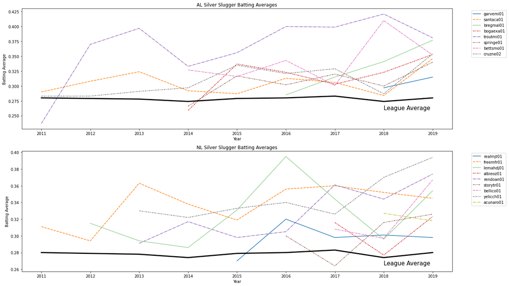

```python
#Makes 2 plots and sets the size
fig, axes = plt.subplots(2,1)
fig.set_size_inches(18.5, 10.5, forward=True)
# Plots our data with x being the year and y being batting average
plot1 =sns.lineplot(ax = axes[0], data=ssAL,x = 'yearID',y = 'BA',hue = 'playerID', style = 'playerID')
plot2 =sns.lineplot(ax = axes[1], data=ssNL,x = 'yearID',y = 'BA',hue = 'playerID', style = 'playerID')
# Moves the legend outside the plot and to the right
plot1.legend(bbox_to_anchor=(1.04,1), loc="upper left")
plot2.legend(bbox_to_anchor=(1.04,1), loc="upper left")
#Sets the title of the plots
plot1.title.set_text("AL Silver Slugger Batting Averages")
plot2.title.set_text("NL Silver Slugger Batting Averages")
#Sets the labels
plot1.set_xlabel("Year")
plot2.set_xlabel("Year")
plot1.set_ylabel("Batting Average")
plot2.set_ylabel("Batting Average")
#Creates a line following the League average and annotates it
plot1.plot(years,averageBAYear,color = 'black',linewidth = 3)
plot2.plot(years,averageBAYear,color = 'black',linewidth = 3)
plot1.annotate('League Average', xy= (2018,.260),size = 15)
plot2.annotate('League Average', xy= (2018,.265),size = 15)
fig.tight_layout()
```

We now have our first graphs! The thick, black line labeled League Average is, as stated, the League Average. As these are the best hitters, we should've been able to predict that these hitter will be well above the line in 2019, but now we can see just how much above they are.

Most of the players have been above average there entire career. However, it is very impressive for the top Batting Averages of both leagues to be .100 higher than the average. This means they would get an extra hit every 10 at bats. Although that doesn't seem like a lot, when the average amount of at bats a plyer gets is over 100, this means in a season the best hitters would be getting 10+ more hits than the normal player. The more hits, the more chances a player gives their team to win, thus being a positive influence on the game's outcome.

We will now repeat this exact same process 3 more times for each of the other stats. We don't have to make the total batters per year list again as it was made before. Now each time we will just be getting the totals before dividing

```python
OBPTotal = [0]*9
averageOBP = [0]*9
for i in range(data.shape[0]):
    if data.iat[i,1] == 2011:
        OBPTotal[0] += data.iat[i,26]
    elif data.iat[i,1] == 2012:
        OBPTotal[1] += data.iat[i,26]
    elif data.iat[i,1] == 2013:
        OBPTotal[2] += data.iat[i,26]
    elif data.iat[i,1] == 2014:
        OBPTotal[3] += data.iat[i,26]
    elif data.iat[i,1] == 2015:
        OBPTotal[4] += data.iat[i,26]
    elif data.iat[i,1] == 2016:
        OBPTotal[5] += data.iat[i,26]
    elif data.iat[i,1] == 2017:
        OBPTotal[6] += data.iat[i,26]
    elif data.iat[i,1] == 2018:
        OBPTotal[7] += data.iat[i,26]
    elif data.iat[i,1] == 2019:
        OBPTotal[8] += data.iat[i,26]

for i in range(0,9):
    averageOBP[i] = round(OBPTotal[i]/batterYear[i],3)

averageOBP
```

```
[0.319, 0.317, 0.316, 0.313, 0.317, 0.321, 0.325, 0.317, 0.323]
```

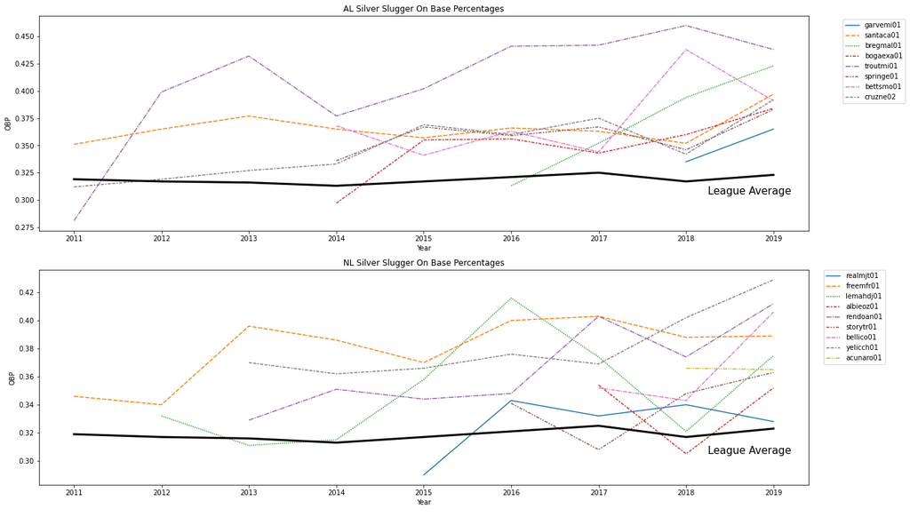

```python
fig, axes = plt.subplots(2,1)
fig.set_size_inches(18.5, 10.5, forward=True)
plot1 =sns.lineplot(ax = axes[0], data=ssAL,x = 'yearID',y = 'OBP',hue = 'playerID', style = 'playerID')
plot2 =sns.lineplot(ax = axes[1], data=ssNL,x = 'yearID',y = 'OBP',hue = 'playerID', style = 'playerID')
plot1.legend(bbox_to_anchor=(1.04,1), loc="upper left")
plot2.legend(bbox_to_anchor=(1.04,1), loc="upper left")
plot1.title.set_text("AL Silver Slugger On Base Percentages")
plot2.title.set_text("NL Silver Slugger On Base Percentages")
plot1.set_xlabel("Year")
plot2.set_xlabel("Year")
plot1.set_ylabel("OBP")
plot2.set_ylabel("OBP")
plot1.plot(years,averageOBP,color = 'black',linewidth = 3)
plot2.plot(years,averageOBP,color = 'black',linewidth = 3)
plot1.annotate('League Average', xy= (2018,.260),size = 15)
plot2.annotate('League Average', xy= (2018,.265),size = 15)
fig.tight_layout()
plt.xticks([2011,2012,2013,2014,2015,2016,2017,2018,2019])
plt.legend(bbox_to_anchor=(1.02, 1), loc='upper left', borderaxespad=0)
plot1.annotate('League Average', xy= (2018.25,.305),size = 15)
plot2.annotate('League Average', xy= (2018.25,.305),size = 15)
```

```python
#Get BA and OBP from the data table
X = data['BA']
y = data['OBP']
#Makes a matrix to check correlation of BA and OBP
correlation_matrix = np.corrcoef(X, y)
correlation_xy = correlation_matrix[0,1]
r_squared = correlation_xy**2

print(r_squared)
```

```
0.8581722953078226
```

A .858 r_squared isn't amazingly high, but shows that there is some correlation between OBP and Batting Average. If we look back at how both are calculated, the both use hits and at bats, however the difference here is the walks. Some players draw a ton of walks as pitchers try not to give them anything to hit. Even know walks aren't as a big of a difference as a home run, they still can lead to runs and crucially are not outs.

Now onto Slugging %!

```python
SluggingTotal = [0]*9
averageSlugging = [0]*9
for i in range(data.shape[0]):
    if data.iat[i,1] == 2011:
        SluggingTotal[0] += data.iat[i,27]
    elif data.iat[i,1] == 2012:
        SluggingTotal[1] += data.iat[i,27]
    elif data.iat[i,1] == 2013:
        SluggingTotal[2] += data.iat[i,27]
    elif data.iat[i,1] == 2014:
        SluggingTotal[3] += data.iat[i,27]
    elif data.iat[i,1] == 2015:
        SluggingTotal[4] += data.iat[i,27]
    elif data.iat[i,1] == 2016:
        SluggingTotal[5] += data.iat[i,27]
    elif data.iat[i,1] == 2017:
        SluggingTotal[6] += data.iat[i,27]
    elif data.iat[i,1] == 2018:
        SluggingTotal[7] += data.iat[i,27]
    elif data.iat[i,1] == 2019:
        SluggingTotal[8] += data.iat[i,27]

for i in range(0,9):
    averageSlugging[i] = round(SluggingTotal[i]/batterYear[i],3)

averageSlugging
```

```
[0.395, 0.401, 0.394, 0.383, 0.407, 0.413, 0.425, 0.406, 0.435]
```

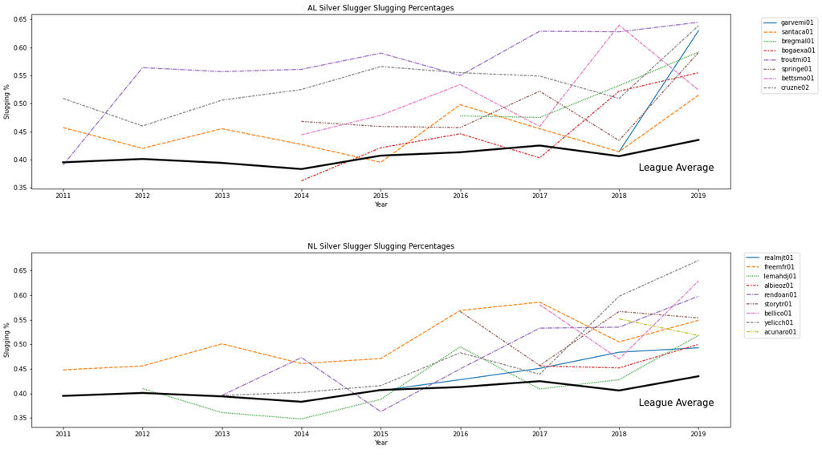

```python
fig, axes = plt.subplots(2,1)
fig.set_size_inches(18.5, 10.5, forward=True)
plot1 =sns.lineplot(ax = axes[0], data=ssAL,x = 'yearID',y = 'SLG',hue = 'playerID', style = 'playerID')
plot2 =sns.lineplot(ax = axes[1], data=ssNL,x = 'yearID',y = 'SLG',hue = 'playerID', style = 'playerID')
plot1.legend(bbox_to_anchor=(1.04,1), loc="upper left")
plot2.legend(bbox_to_anchor=(1.04,1), loc="upper left")
plot1.title.set_text("AL Silver Slugger Slugging Percentages")
plot2.title.set_text("NL Silver Slugger Slugging Percentages")
plot1.set_xlabel("Year")
plot2.set_xlabel("Year")
plot1.set_ylabel("Slugging %")
plot2.set_ylabel("Slugging %")
plot1.plot(years,averageSlugging,color = 'black',linewidth = 3)
plot2.plot(years,averageSlugging,color = 'black',linewidth = 3)
plot1.annotate('League Average', xy= (2018,.260),size = 15)
plot2.annotate('League Average', xy= (2018,.265),size = 15)
fig.tight_layout()
plt.xticks([2011,2012,2013,2014,2015,2016,2017,2018,2019])
plt.legend(bbox_to_anchor=(1.02, 1), loc='upper left', borderaxespad=0)
plot1.annotate('League Average', xy= (2018.25,.380),size = 15)
plot2.annotate('League Average', xy= (2018.25,.375),size = 15)
```

As was the case for BA and OBP, the League average is low compared to the best batters. In this case, the best of the best are even .200+ above. This means that most of the best hitters produce a lot of extra base hits. Slugging looks at the total number of bases a batter gets, meaning a homerun counts 4 times as much as a single.

And now for OPS

```python
averageOPS = [0]*9
for i in range(0,9):
    averageOPS[i] = round(averageSlugging[i]+averageOBP[i],3)

averageOPS
```

```
[0.714, 0.718, 0.71, 0.696, 0.724, 0.734, 0.75, 0.723, 0.758]
```

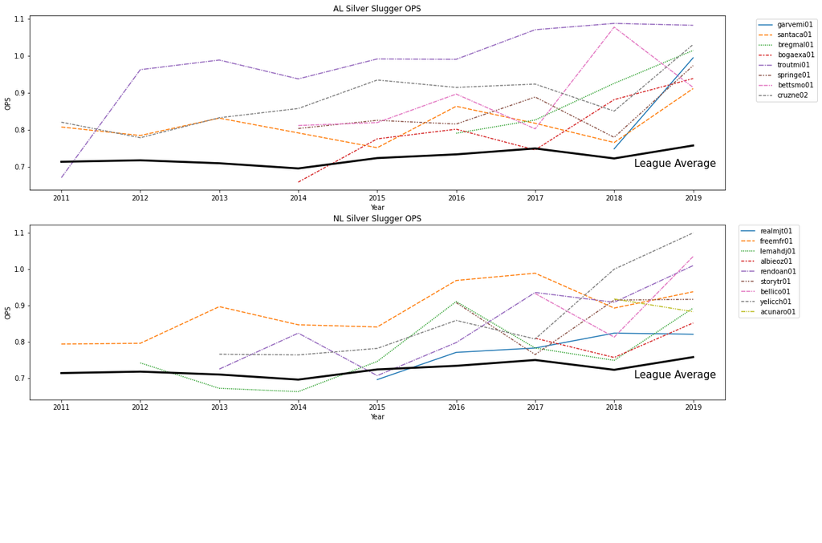

```python
fig, axes = plt.subplots(2,1)
fig.set_size_inches(18.5, 10.5, forward=True)
plot1 =sns.lineplot(ax = axes[0], data=ssAL,x = 'yearID',y = 'OPS',hue = 'playerID', style = 'playerID')
plot2 =sns.lineplot(ax = axes[1], data=ssNL,x = 'yearID',y = 'OPS',hue = 'playerID', style = 'playerID')
plot1.legend(bbox_to_anchor=(1.04,1), loc="upper left")
plot2.legend(bbox_to_anchor=(1.04,1), loc="upper left")
plot1.title.set_text("AL Silver Slugger OPS")
plot2.title.set_text("NL Silver Slugger OPS")
plot1.set_xlabel("Year")
plot2.set_xlabel("Year")
plot1.set_ylabel("OPS")
plot2.set_ylabel("OPS")
plot1.plot(years,averageOPS,color = 'black',linewidth = 3)
plot2.plot(years,averageOPS,color = 'black',linewidth = 3)
plot1.annotate('League Average', xy= (2018,.260),size = 15)
plot2.annotate('League Average', xy= (2018,.265),size = 15)
plt.xticks([2011,2012,2013,2014,2015,2016,2017,2018,2019])
plt.legend(bbox_to_anchor=(1.02, 1), loc='upper left', borderaxespad=0)
plot1.annotate('League Average', xy= (2018.25,.7),size = 15)
plot2.annotate('League Average', xy= (2018.25,.7),size = 15)
```

Since OPS is just OBP and Slugging, any difference between Silver Sluggers and the average will just be added. Thus we see the best be further ahead of the league average while the gap also opening up.

# 3 Key Statistics

## 3.1 Null Hypothesis

We are looking at the impact of 4 difference batting statistics on the WAR of a batter.

**Null Hypohtesis: None of the attributes will have an impact on WAR**

To test the null hypothesis, we will perform Multiple Linear Regression on the data.

Before we do any regression we must make our data table that we will be using. As we have 2019 WAR data we will be making a new table with only batters who played in 2019, once again with 100+ ABs.

```python
only2019 = pd.DataFrame()
#Add to the new table only those that
only2019 = only2019.append(data.loc[data['yearID'] == 2019])
only2019['WAR'] = np.nan
only2019 = only2019.drop(columns = ['nameLast','nameGiven','GIDP','SF','SH','HBP','IBB'])
```

```python
i = 0

#To add WAR to the normal table, check both first and last name of the player
#This is because some of the ones on Fan Graphs are no the given name, but nicknames
only2019WAR = pd.DataFrame()
for i in range(only2019.shape[0]):
    for j in range(fanGraphs.shape[0]):
        if fanGraphs.iat[j,0] in only2019.iat[i,17]:
            if fanGraphs.iat[j,1] in only2019.iat[i,17]:
                only2019.iat[i,22] = fanGraphs.iat[j,22]
                only2019WAR = only2019WAR.append(only2019.loc[only2019['playerID'] == only2019.iat[i,0]])

only2019WAR.head()
```

|  | playerID | yearID | stint | teamID | lgID | G | AB | R | H | 2B | ... | SB | CS | BB | SO | nameFull | BA | OBP | SLG | OPS | WAR |
| --- | --- | --- | --- | --- | --- | --- | --- | --- | --- | --- | --- | --- | --- | --- | --- | --- | --- | --- | --- | --- | --- |
| 105862 | abreujo02 | 2019 | 1 | CHA | AL | 159 | 634 | 85 | 180 | 38 | ... | 2.0 | 2.0 | 36 | 152.0 | Jose Dariel Abreu | 0.301 | 0.330 | 0.503 | 0.833 | 1.7 |
| 105863 | acunaro01 | 2019 | 1 | ATL | NL | 156 | 626 | 127 | 175 | 22 | ... | 37.0 | 9.0 | 76 | 188.0 | Ronald Jose Acuna | 0.318 | 0.365 | 0.518 | 0.883 | 5.5 |
| 105865 | adamewi01 | 2019 | 1 | TBA | AL | 152 | 531 | 69 | 135 | 25 | ... | 4.0 | 2.0 | 46 | 153.0 | Willy Rafael Adames | 0.278 | 0.317 | 0.418 | 0.735 | 2.9 |
| 105881 | alberha01 | 2019 | 1 | BAL | AL | 139 | 524 | 62 | 160 | 21 | ... | 4.0 | 4.0 | 16 | 50.0 | Hanser Joel Alberto | 0.315 | 0.329 | 0.422 | 0.751 | 1.9 |
| 105900 | alonspe01 | 2019 | 1 | NYN | NL | 161 | 597 | 103 | 155 | 30 | ... | 1.0 | 0.0 | 72 | 183.0 | Peter Morgan Alonso | 0.295 | 0.358 | 0.583 | 0.941 | 4.9 |

5 rows × 23 columns

We now have a table with all of the players that we have WARs for. This is what we will use for analysis and the rest of the project. For neatness, we will now also sort the table by WAR.

```python
only2019WAR = only2019WAR.sort_values(by='WAR', ascending=False)
only2019WAR = only2019WAR.dropna(axis = 0)
```

```python
only2019WAR
```

|  | playerID | yearID | stint | teamID | lgID | G | AB | R | H | 2B | ... | SB | CS | BB | SO | nameFull | BA | OBP | SLG | OPS | WAR |
| --- | --- | --- | --- | --- | --- | --- | --- | --- | --- | --- | --- | --- | --- | --- | --- | --- | --- | --- | --- | --- | --- |
| 106046 | bregmal01 | 2019 | 1 | HOU | AL | 156 | 554 | 122 | 164 | 37 | ... | 5.0 | 1.0 | 119 | 83.0 | Alexander David Bregman | 0.377 | 0.423 | 0.592 | 1.015 | 8.4 |
| 107287 | troutmi01 | 2019 | 1 | LAA | AL | 134 | 470 | 110 | 137 | 27 | ... | 11.0 | 2.0 | 110 | 120.0 | Michael Nelson Trout | 0.381 | 0.438 | 0.645 | 1.083 | 8.4 |
| 107415 | yelicch01 | 2019 | 1 | MIL | NL | 130 | 489 | 100 | 161 | 29 | ... | 30.0 | 2.0 | 80 | 118.0 | Christian Stephen Yelich | 0.394 | 0.429 | 0.671 | 1.100 | 7.8 |
| 105988 | bellico01 | 2019 | 1 | LAN | NL | 156 | 558 | 121 | 170 | 34 | ... | 15.0 | 5.0 | 95 | 108.0 | Cody James Bellinger | 0.367 | 0.406 | 0.629 | 1.035 | 7.7 |
| 107131 | semiema01 | 2019 | 1 | OAK | AL | 162 | 657 | 123 | 187 | 43 | ... | 10.0 | 8.0 | 87 | 102.0 | Marcus Andrew Semien | 0.328 | 0.369 | 0.522 | 0.891 | 7.6 |
| ... | ... | ... | ... | ... | ... | ... | ... | ... | ... | ... | ... | ... | ... | ... | ... | ... | ... | ... | ... | ... | ... |
| 106081 | cabremi01 | 2019 | 1 | DET | AL | 136 | 493 | 41 | 139 | 21 | ... | 0.0 | 0.0 | 48 | 108.0 | Jose Miguel Cabrera | 0.312 | 0.346 | 0.398 | 0.744 | -0.3 |
| 106541 | hosmeer01 | 2019 | 1 | SDN | NL | 160 | 619 | 72 | 164 | 29 | ... | 0.0 | 3.0 | 40 | 163.0 | Eric John Hosmer | 0.283 | 0.310 | 0.425 | 0.735 | -0.3 |
| 105931 | arciaor01 | 2019 | 1 | MIL | NL | 152 | 494 | 51 | 110 | 16 | ... | 8.0 | 5.0 | 43 | 109.0 | Orlando Jesus Arcia | 0.244 | 0.283 | 0.350 | 0.633 | -0.4 |
| 106975 | pujolal01 | 2019 | 1 | LAA | AL | 131 | 491 | 55 | 120 | 22 | ... | 3.0 | 0.0 | 43 | 68.0 | Jose Alberto Pujols | 0.268 | 0.305 | 0.430 | 0.735 | -0.6 |
| 106194 | daviskh01 | 2019 | 1 | OAK | AL | 133 | 481 | 61 | 106 | 11 | ... | 0.0 | 0.0 | 47 | 146.0 | Khristopher Adrian Davis | 0.244 | 0.293 | 0.387 | 0.680 | -0.9 |

127 rows × 23 columns

## 3.2 Regression

Here we will use our new only2019WAR table to test our null hypothesis. First we need 2 tables, the first will be those attributes we are testing for their impact. This is like the x variable of a graph or the independent variable. The second is the dependent variable which is the WAR. In this case, the x will be features and the y will be the target.

```python
grouped_attrs = ['BA','OBP','SLG','OPS']
features = only2019WAR[grouped_attrs]
target = only2019WAR[['WAR']]
```

Using now we will use the LinearRegression() function. For this we need an X and a y. Like before, it will be the features and target. Then we check the fit. This is done with the .score(X,y).

```python
X = features
y = target['WAR']
lm = linear_model.LinearRegression()
model = lm.fit(X,y)
lm.score(X,y)
```

```
0.6995117162591307
```

This gives us an r_squared value like before. As this is only .700 we aren't as correlated as the other data we checked. However, it isn't horrible by any means. There is some correlation between our independent and dependent variables.

```python
sk_coeff = lm.coef_.tolist()
for attr, coef in zip(grouped_attrs, sk_coeff):
    print('Attribute: {}, Coefficient: {}'.format(attr,coef))
```

```
Attribute: BA, Coefficient: 1.9535546058447024
Attribute: OBP, Coefficient: 159779615953254.38
Attribute: SLG, Coefficient: 159779615953241.06
Attribute: OPS, Coefficient: -159779615953227.6
```

Since OBP and SLG have such a huge coefficient it is possible to say that this proves our null hypothesis false.

# 4 Predicting the WAR with Machine Learning

## 4.1 Predictions with Training and Testing

To start we need to set up parameters. From X and y, we will use the exact same as we did in 3. With BA, OBP, OPS and SLG being the X and WAR being the Y.

The difference here is that there are 2 X's and 2 Y's. For both we have a train and a test. Train is used to generate the model that our machine will be using. While testing will used to make prediction for expected WAR. This is then compared to the actual WAR we have which will be put in y_test.

We try to use as much of the data to train as possible. As we are limited by the data we have we will give 100 of the 130 to training(around a 75-25 split).

```python
#create data from X and y from part 3
X_train, X_test, y_train, y_test = model_selection.train_test_split(X, y, test_size=0.25)
#make the model
lm = linear_model.LinearRegression()
model = lm.fit(X_train, y_train)
#create predictions and compare to actual
predictions = lm.predict(X_test)
```

We will now plot the data, predicted vs actual to see how our machine learning did. For this, we plot y test against predictions. We then add a line which is just y_test vs itself for a trendline to see how closs our dots are to the actual WARs of the players.

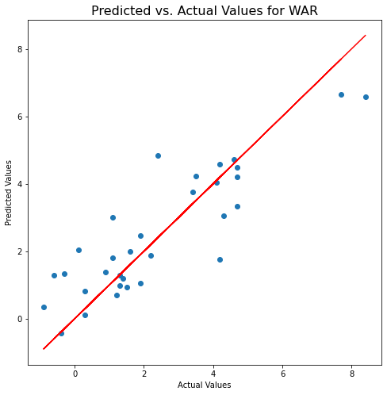

```python
plt.figure(figsize = (8,8))
plt.title("Predicted vs. Actual Values for WAR", fontsize=16)
plt.scatter(y_test, predictions)
plt.plot(y_test, y_test, color = "Red")
plt.xlabel("Actual Values")
plt.ylabel("Predicted Values")
plt.show()
```

```python
print("Accuracy: {}".format(model.score(X_test, y_test)))
```

```
Accuracy: 0.7587408711721728
```

Our graph shows that we are generally close to the actual WAR of the players, but are not perfect. This can also be seen with our accuracy score of 75.9%. A C is passing but not what we would strive for.

# 5. Conclusion

## 5.1 Key Attributes

With this in mind, it seems that a batter must do what it takes to get on base, even if it is to draw a walk every time they are up to bat.

One would think that SLG % would have a bigger contribution to WAR. If a batter were to only it homeruns, they would be one of the most impactful hitters in history (Like Barry Bonds). However, even someone who doesn't watch baseball knows that this is impossible. Thus SLG% seems to have a cap on how high it can get in reality.

## 5.2 Prediction of WAR

The "low" accuracy of our predictions may be from a small case of underfitting. Although the predictions match the main shape, the amount of data we had to work with (130 observations) is low compared to other samples that are done with machine learning. If the data set were closer to 1000 or 2000, the accuracy may be able to increase marginally.

## 5.3 Future Analysis

If further analysis was to be done. Expanding the dataset is a must. Furthermore, being able to see if there is a trend between WAR in the past years before a Silver Slugger year would allow predictions to be stronger as well. The goal would be to find the Silver Slugger 5 years in the future, not just of present day.